# I Spy Garbage: Model Building

I used the data set linked here: https://www.kaggle.com/datasets/asdasdasasdas/garbage-classification

I have gone ahead and manually divided the sets of images for each material into training and testing sets, where testing sets compose of the last 20% of images in each folder. None of the images are in any particular order, so this should be fine opposed to doing a randomized split (though this topic could be explored further).

It can be quite difficult to gather data manually, which is why I use a data set that is already organized.

## Setup for our model

```r
# Importing libraries
library(tidyverse)
library(mlflow)
library(keras)
library(tensorflow)
library(reticulate)
```

I will also go ahead and set the random seed. I also go ahead and set an environmental variable to 0 since it caused a warning when I ran this for the first time.

```r
# Setting seed for reproducible results
set_random_seed(220, disable_gpu = TRUE)
```

[output not shown]

```r
# Turning off any potential floating-point round-off errors
TF_ENABLE_ONEDNN_OPTS=0
```

Next, I create a list of each label for all our potential material classifications. I set my current working directory to the `model` directory in my project.

```r
# Get a unique list of all material types
label_list <- dir("train_images/")
output_n <- length(label_list)
save(label_list, file="label_list.R")
```

I also go ahead and set some parameters for image re-scaling. This will be quite useful since it will mean the images we put into the model after it is built will not require specific formatting from the user.

```r
# Setting dimensions for images
width <- 224
height <- 224
target_size <- c(width, height)

# Number of color changes
rgb <- 3
```

I also will set the path to our training data.

```r
path_train <- "train_images/"
```

```r
train_data_gen <- image_data_generator(rescale = 1/255, validation_split = .25)
```

Now I use a function called `flow_images_from_directory` to batch process our images with the generator function we defined above. I link this up to our training and validation data, and set some basic parameters.

```r
train_images <- flow_images_from_directory(path_train,
                                           train_data_gen,
                                           subset = 'training',
                                           target_size = target_size,
                                           class_mode = "categorical",
                                           shuffle=F,
                                           classes = label_list,
                                           seed = 220)
```

```
Found 1516 images belonging to 6 classes.
```

```r
validation_images <- flow_images_from_directory(path_train,
                                                train_data_gen,
                                                subset = 'validation',
                                                target_size = target_size,
                                                class_mode = "categorical",
                                                classes = label_list,
                                                seed = 220)
```

```
Found 504 images belonging to 6 classes.
```

I will note that I could have just used separate folders for training and validation, but I just chose to let `keras` do it with a random split.

To check the work so far, I output a table of our classes in our training images.

```r
table(train_images$classes)
```

```
  0   1   2   3   4   5
240 300 246 357 290  83
```

This corresponds to the number of pictures in each folder.

## Training the model:

Given the nature of this project, I will be using a convoluted neural network (CNN).

For the sake of this project, there is a way I can ensure good baseline results, by using models that were pre-trained in the past for other applications. I choose the xception-network with the weights pre-trained on the ImageNet data set, a large data set used for object recognition. However, I will edit the final layers, since this is the output layer that classifies the images, and of course, I need to adjust it to train for our own sets of images This is done by setting the parameter `include_top` to FALSE.

```r
mod_base <- application_xception(weights = 'imagenet', include_top = FALSE, input_shape = c(width, height, 3))
```

[output not shown]

```r
freeze_weights(mod_base) # we freeze the weights so they are no longer trainable,
```

Below, I define a function that will build that final layer that we left out from the `imagenet` model. I set some parameters to variables that we will use to fine-tune our model later.

```r
# learning_rate controls step size in backpropagation
# E.g. new weights = old weight - learning_rate * gradient

# dropout_rate sets the proportion of neurons to turn off per epoch,
# which helps with promoting diversity by limiting the data per epoch

# n_dense sets the number of output neurons that become fully connected
# with every input neuron for that layer
model_function <- function(learning_rate=0.0001, dropout_rate=0.2,
                            n_dense=1024){

  # Resets all generated states
  k_clear_session()

  # Setup the architecture of model, which is needed for CNN (or NNs in general)
  # Sequential is used since we have multiple layers to define
  model <- keras_model_sequential() %>%
    # mod_base takes the base CNN from `imagenet``
    mod_base %>%

    # Get a pooling layer to help reduce size of images by getting the most potent pixels within a small area (still able to capture significant patterns)
    layer_global_average_pooling_2d() %>%

    layer_dense(units = n_dense) %>%

    # Relu activation function to help look for non-linear relationships (since NN layers are linear in nature, since you just multiply a numerical weight from each input neuron, and add a bias similar to regression)
    layer_activation("relu") %>%

    layer_dropout(rate = dropout_rate, seed = 220) %>%

    # Final layer is the softmax activation function, to convert all the values into a final prediction for multi-class classification
    layer_dense(units=output_n, activation="softmax")

  # Setup the architecture with the loss function, learning rate with the chosen     optimizer function (controls how weights get updated in backprop), and the      scoring metric to use
  model %>% compile(
    loss = "categorical_crossentropy",
    optimizer = optimizer_adam(learning_rate = learning_rate),
    metrics = "accuracy"
  )

  return(model)
}
```

Now, I let the model compile with those base values and inspect the architecture.

```r
model <- model_function()
model
```

```
Model: "sequential"
______________________________________________________________________________________________________________________________________________________
 Layer (type)                                                 Output Shape                                            Param #              Trainable
======================================================================================================================================================
 xception (Functional)                                        (None, 7, 7, 2048)                                      20861480             N
 global_average_pooling2d (GlobalAveragePooling2D)            (None, 2048)                                            0                    Y
 dense_1 (Dense)                                              (None, 1024)                                            2098176              Y
 activation (Activation)                                      (None, 1024)                                            0                    Y
 dropout (Dropout)                                            (None, 1024)                                            0                    Y
 dense (Dense)                                                (None, 6)                                               6150                 Y
======================================================================================================================================================
Total params: 22965806 (87.61 MB)
Trainable params: 2104326 (8.03 MB)
Non-trainable params: 20861480 (79.58 MB)
______________________________________________________________________________________________________________________________________________________
```

We can see that we have 20 million parameters from the xception model that are non-trainable, since we only train the top layer, which is a 1024 x 1 feature vector that is densely connected to the output classification layer. This is essentially 1024 variables, which take on certain values depending on if our image has certain properties, and all of this is trained during the convolution layers of the xception network (aka the ‘black box’).

With that said, let is train the model with our training data now!

```r
# Number of training samples fed to our neural network at once
batch_size <- 32
# Number of times our entire training data set is passed through the neural network
epochs <- 6

hist <- model %>% fit_generator(
  train_images,

  # Specify number of steps based on # of total images divided by batch size
  steps_per_epoch = train_images$n %/% batch_size,

  epochs = epochs,
  validation_data = validation_images,

  # Specify number of steps based on # of total images divided by batch size
  validation_steps = validation_images$n %/% batch_size,
  verbose = 2
)
```

[output not shown]

[output not shown]

## Testing our model

For fun, I will use a candy wrapper image that was not in our training data to test out how our model predicts it. Again, with how I setup the model beforehand, there is no need for me to “set up” the image beforehand with a specific dimension and such - the model will do that automatically.

```r
test_image <- image_load("test_image.jpg",
                         target_size = target_size)

# Preprocessing the image
x <- image_to_array(test_image)
x <- array_reshape(x, c(1, dim(x)))
x <- x/255

# Make prediction with our image
pred <- model %>% predict(x)
pred <- data.frame("Type of Waste" = label_list, "Probability" = t(pred))
pred <- pred[order(pred$Probability, decreasing=T),][1:6,]
pred$Probability <- paste(format(100*pred$Probability,2),"%")
pred
```

|  | Type.of.Waste | Probability |
| --- | --- | --- |
| 4 | paper | 88.3502603 % |
| 1 | cardboard | 4.4261891 % |
| 6 | trash | 3.6199342 % |
| 3 | metal | 2.7097275 % |
| 5 | plastic | 0.5411810 % |
| 2 | glass | 0.3527015 % |

Looks like the model predicted correctly, since this is a mostly paper candy wrapper.

Now I raise a question. Is there a particular type of material in our classification that our model does not accurately predict (which would be the main source of our lower accuracy)? The code block below will show us just that.

I will generate a matrix of all predictions for each image in our validation data for every material type. I label the highest prediction as the predicted class and then compare it with the actual correct class to get the % of correct classifications.

```r
# Predicting with our model with the validation images
predictions <- model %>%
  predict_generator(
    generator = validation_images,
    steps = validation_images$n
  ) %>% as.data.frame
```

[output not shown]

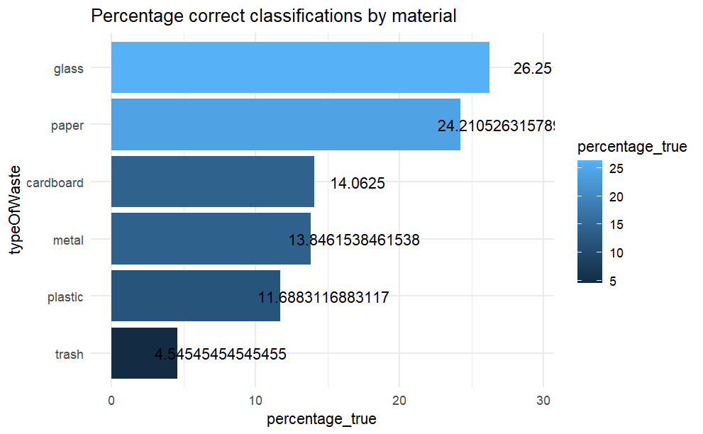

```r
names(predictions) <- paste0("Class",0:5)

# Bunch of various data processing to get the data into the right form for the graph
predictions$predicted_class <-
  paste0("Class",apply(predictions,1,which.max)-1)
predictions$true_class <- paste0("Class",validation_images$classes)

predictions %>% group_by(true_class) %>%
  summarise(percentage_true = 100*sum(predicted_class ==
                                        true_class)/n()) %>%
  left_join(data.frame(typeOfWaste = names(validation_images$class_indices),
                       true_class = paste0("Class",0:5)), by="true_class") %>%
  select(typeOfWaste, percentage_true) %>%
  mutate(typeOfWaste = fct_reorder(typeOfWaste,percentage_true)) %>%
  ggplot(aes(x=typeOfWaste,y=percentage_true,fill=percentage_true,
             label=percentage_true)) +
  geom_col() + theme_minimal() + coord_flip() +
  geom_text(nudge_y = 3) +
  ggtitle("Percentage correct classifications by material")
```

I can see that the trash category does not appear to get accurate classifications. This makes sense as well, since this is a broad category with many images of different things that are not extremely similar with one another, compared to the other categories with a well established theme.

## Tuning our model

So there are multiple ways to try and solve the problem with our model having poor accuracy. I could just try and gather more image data for the trash category, but given this is more of a broad category, this may not be that easy. So instead, I try tuning the model with MLFlow to be able to test different sets of hyperparameters, and find the one with the best performance on the validation images.

This is basically just grid search - I could not find other popular hyperparameter tuning algorithms like Tree of Parzen Estimators that were built in with R, so I got lazy and just went with this approach. Certainly, this would be more efficient if more research was done, or if I wanted to implement my own algorithm.

```r
# https://cran.r-project.org/web/packages/mlflow/readme/README.html
# More things could be added to the mlflow workflow (more metrics, loss functions, artifacts, etc), but for this usecase, I don't think its necessary, since training takes a long time as is

# Run "mlflow ui --backend-store-uri sqlite:///mlflow.db --host 127.0.0.1 --port 5000" in command prompt
mlflow_set_tracking_uri("http://127.0.0.1:5000")

# Set the experiment
mlflow_set_experiment("cnn_sgd_hyperparameter_tuning")
```

```
G3;Experiment `cnn_sgd_hyperparameter_tuning` does not exist. Creating a new experiment.
g
```

```
[1] "1"
```

```r
# Define grid of hyperparameters
# batch_sizes <- c(16, 32) # Original line, now fixed
# epochs_list <- c(4, 6)   # Original line, now fixed
fixed_batch_size_value <- 32
fixed_epochs_value <- 6
learning_rates <- c(0.01, 0.001)
momentums <- c(0.0, 0.9)
dropout_rates <- c(0.3, 0.5)

# Loop through all combinations of hyperparameters
# for (batch_size in batch_sizes) { # Original loop for batch_size removed
#  for (epochs in epochs_list) {   # Original loop for epochs removed
    for (learning_rate in learning_rates) {
      for (momentum in momentums) {
        for (dropout_rate in dropout_rates) {

          # Set the fixed batch_size and epochs for this run
          batch_size <- fixed_batch_size_value
          epochs <- fixed_epochs_value

          with(mlflow_start_run(), {

            # Reinitialize our set of images
            train_images <- flow_images_from_directory(path_train,
                                                     train_data_gen,
                                                     subset = 'training',
                                                     target_size = target_size,
                                                     class_mode = "categorical",
                                                     shuffle=F, # This comment is from your original script
                                                     classes = label_list,
                                                     seed = 220)

            validation_images <- flow_images_from_directory(path_train,
                                                          train_data_gen,
                                                          subset = 'validation',
                                                          target_size = target_size,
                                                          class_mode = "categorical",
                                                          classes = label_list,
                                                          seed = 220)

            # Log current hyperparameters
            mlflow_log_param("batch_size", batch_size)
            mlflow_log_param("epochs", epochs)
            mlflow_log_param("learning_rate", learning_rate)
            mlflow_log_param("momentum", momentum)
            mlflow_log_param("dropout_rate", dropout_rate)

            # Setting up same model architecture as before
            model <- keras_model_sequential() %>%
              mod_base %>%
              layer_global_average_pooling_2d() %>%
              layer_dense(units = 1024) %>%
              layer_activation("relu") %>%
              layer_dropout(rate = dropout_rate, seed = 220) %>%
              layer_dense(units=output_n, activation="softmax")

            # Compile with SGD optimizer instead of adams optimizer
            model %>% compile(
              loss = "categorical_crossentropy",
              optimizer = optimizer_sgd(learning_rate = learning_rate, momentum = momentum),
              metrics = c("accuracy")
            )

            steps_per_epoch <- max(1, floor(train_images$n / batch_size))
            validation_steps <- max(1, floor(validation_images$n / batch_size))

            # Train the model, applying floor so there is always enough data
            hist <- model %>% fit_generator(
              train_images,
              steps_per_epoch = steps_per_epoch,
              epochs = epochs,
              validation_data = validation_images,
              validation_steps = validation_steps,
              verbose = 2
            )

            # Log final validation accuracy
            val_acc <- hist$metrics$val_accuracy[epochs]
            if (!is.null(val_acc) && !is.na(val_acc)) {
              mlflow_log_metric("val_accuracy", val_acc)
            } else {
              message("Warning: val_accuracy is NULL or NA — not logging it.")
              print(val_acc)
            }
          })
        }
      }
    }
```

```
Found 1516 images belonging to 6 classes.
Found 504 images belonging to 6 classes.
```

```
47/47 - 127s - loss: 1.5509 - accuracy: 0.3949 - val_loss: 1.1131 - val_accuracy: 0.6167 - 127s/epoch - 3s/step
47/47 - 107s - loss: 1.0295 - accuracy: 0.6509 - val_loss: 0.9212 - val_accuracy: 0.6979 - 107s/epoch - 2s/step
47/47 - 108s - loss: 0.8267 - accuracy: 0.7230 - val_loss: 0.8580 - val_accuracy: 0.6687 - 108s/epoch - 2s/step
47/47 - 108s - loss: 0.7107 - accuracy: 0.7662 - val_loss: 0.7518 - val_accuracy: 0.7333 - 108s/epoch - 2s/step
47/47 - 109s - loss: 0.6583 - accuracy: 0.7911 - val_loss: 0.7251 - val_accuracy: 0.7396 - 109s/epoch - 2s/step
47/47 - 108s - loss: 0.5875 - accuracy: 0.7985 - val_loss: 0.7176 - val_accuracy: 0.7583 - 108s/epoch - 2s/step
Found 1516 images belonging to 6 classes.
Found 504 images belonging to 6 classes.
```

```
47/47 - 110s - loss: 1.6131 - accuracy: 0.3497 - val_loss: 1.2033 - val_accuracy: 0.5437 - 110s/epoch - 2s/step
47/47 - 107s - loss: 1.1050 - accuracy: 0.5856 - val_loss: 0.9693 - val_accuracy: 0.6708 - 107s/epoch - 2s/step
47/47 - 107s - loss: 0.8891 - accuracy: 0.7001 - val_loss: 0.8330 - val_accuracy: 0.7208 - 107s/epoch - 2s/step
47/47 - 107s - loss: 0.7704 - accuracy: 0.7406 - val_loss: 0.8015 - val_accuracy: 0.7250 - 107s/epoch - 2s/step
47/47 - 108s - loss: 0.6831 - accuracy: 0.7567 - val_loss: 0.8276 - val_accuracy: 0.6792 - 108s/epoch - 2s/step
47/47 - 104s - loss: 0.6041 - accuracy: 0.7925 - val_loss: 0.7756 - val_accuracy: 0.7021 - 104s/epoch - 2s/step
Found 1516 images belonging to 6 classes.
Found 504 images belonging to 6 classes.
```

```
47/47 - 108s - loss: 1.6566 - accuracy: 0.3976 - val_loss: 1.0386 - val_accuracy: 0.5938 - 108s/epoch - 2s/step
47/47 - 106s - loss: 0.7432 - accuracy: 0.7338 - val_loss: 0.7610 - val_accuracy: 0.7104 - 106s/epoch - 2s/step
47/47 - 103s - loss: 0.5994 - accuracy: 0.7803 - val_loss: 1.2055 - val_accuracy: 0.5917 - 103s/epoch - 2s/step
47/47 - 105s - loss: 0.5469 - accuracy: 0.8026 - val_loss: 0.6940 - val_accuracy: 0.7458 - 105s/epoch - 2s/step
47/47 - 105s - loss: 0.4978 - accuracy: 0.8133 - val_loss: 0.6349 - val_accuracy: 0.7646 - 105s/epoch - 2s/step
47/47 - 105s - loss: 0.3292 - accuracy: 0.8740 - val_loss: 0.6213 - val_accuracy: 0.7667 - 105s/epoch - 2s/step
Found 1516 images belonging to 6 classes.
Found 504 images belonging to 6 classes.
```

```
47/47 - 109s - loss: 1.7097 - accuracy: 0.4151 - val_loss: 0.9966 - val_accuracy: 0.6438 - 109s/epoch - 2s/step
47/47 - 102s - loss: 1.0460 - accuracy: 0.6105 - val_loss: 0.8245 - val_accuracy: 0.7167 - 102s/epoch - 2s/step
47/47 - 104s - loss: 0.6846 - accuracy: 0.7628 - val_loss: 0.7660 - val_accuracy: 0.7437 - 104s/epoch - 2s/step
47/47 - 104s - loss: 0.5399 - accuracy: 0.8127 - val_loss: 0.7225 - val_accuracy: 0.7396 - 104s/epoch - 2s/step
47/47 - 104s - loss: 0.5409 - accuracy: 0.8019 - val_loss: 0.6695 - val_accuracy: 0.7167 - 104s/epoch - 2s/step
47/47 - 104s - loss: 0.4074 - accuracy: 0.8464 - val_loss: 0.6373 - val_accuracy: 0.7729 - 104s/epoch - 2s/step
Found 1516 images belonging to 6 classes.
Found 504 images belonging to 6 classes.
```

```
47/47 - 102s - loss: 1.8114 - accuracy: 0.2069 - val_loss: 1.6691 - val_accuracy: 0.3042 - 102s/epoch - 2s/step
47/47 - 105s - loss: 1.6534 - accuracy: 0.3329 - val_loss: 1.5692 - val_accuracy: 0.4208 - 105s/epoch - 2s/step
47/47 - 104s - loss: 1.5606 - accuracy: 0.3915 - val_loss: 1.4732 - val_accuracy: 0.4750 - 104s/epoch - 2s/step
47/47 - 104s - loss: 1.4803 - accuracy: 0.4663 - val_loss: 1.4059 - val_accuracy: 0.5500 - 104s/epoch - 2s/step
47/47 - 103s - loss: 1.3829 - accuracy: 0.5418 - val_loss: 1.3451 - val_accuracy: 0.5708 - 103s/epoch - 2s/step
47/47 - 104s - loss: 1.3060 - accuracy: 0.5937 - val_loss: 1.2821 - val_accuracy: 0.6021 - 104s/epoch - 2s/step
Found 1516 images belonging to 6 classes.
Found 504 images belonging to 6 classes.
```

```
47/47 - 105s - loss: 1.8307 - accuracy: 0.2075 - val_loss: 1.6764 - val_accuracy: 0.3313 - 105s/epoch - 2s/step
47/47 - 102s - loss: 1.7014 - accuracy: 0.2682 - val_loss: 1.5766 - val_accuracy: 0.4521 - 102s/epoch - 2s/step
47/47 - 100s - loss: 1.5834 - accuracy: 0.3827 - val_loss: 1.4913 - val_accuracy: 0.5271 - 100s/epoch - 2s/step
47/47 - 121s - loss: 1.5044 - accuracy: 0.4225 - val_loss: 1.4223 - val_accuracy: 0.5646 - 121s/epoch - 3s/step
47/47 - 101s - loss: 1.4308 - accuracy: 0.4784 - val_loss: 1.3575 - val_accuracy: 0.6021 - 101s/epoch - 2s/step
47/47 - 104s - loss: 1.3387 - accuracy: 0.5451 - val_loss: 1.3030 - val_accuracy: 0.6375 - 104s/epoch - 2s/step
Found 1516 images belonging to 6 classes.
Found 504 images belonging to 6 classes.
```

```
47/47 - 105s - loss: 1.7736 - accuracy: 0.2648 - val_loss: 1.2656 - val_accuracy: 0.5500 - 105s/epoch - 2s/step
47/47 - 109s - loss: 1.0740 - accuracy: 0.6213 - val_loss: 1.0536 - val_accuracy: 0.6167 - 109s/epoch - 2s/step
47/47 - 109s - loss: 0.8562 - accuracy: 0.7015 - val_loss: 0.8609 - val_accuracy: 0.6792 - 109s/epoch - 2s/step
47/47 - 105s - loss: 0.7577 - accuracy: 0.7284 - val_loss: 0.8100 - val_accuracy: 0.6917 - 105s/epoch - 2s/step
47/47 - 107s - loss: 0.6670 - accuracy: 0.7743 - val_loss: 0.7699 - val_accuracy: 0.7271 - 107s/epoch - 2s/step
47/47 - 105s - loss: 0.6223 - accuracy: 0.7770 - val_loss: 0.7125 - val_accuracy: 0.7250 - 105s/epoch - 2s/step
Found 1516 images belonging to 6 classes.
Found 504 images belonging to 6 classes.
```

```
47/47 - 110s - loss: 1.6425 - accuracy: 0.3383 - val_loss: 1.2450 - val_accuracy: 0.5333 - 110s/epoch - 2s/step
47/47 - 98s - loss: 1.1134 - accuracy: 0.6085 - val_loss: 0.9652 - val_accuracy: 0.6917 - 98s/epoch - 2s/step
47/47 - 101s - loss: 0.8692 - accuracy: 0.7015 - val_loss: 0.8683 - val_accuracy: 0.6958 - 101s/epoch - 2s/step
47/47 - 101s - loss: 0.8087 - accuracy: 0.7008 - val_loss: 0.7806 - val_accuracy: 0.7458 - 101s/epoch - 2s/step
47/47 - 100s - loss: 0.7143 - accuracy: 0.7520 - val_loss: 0.7887 - val_accuracy: 0.7188 - 100s/epoch - 2s/step
47/47 - 100s - loss: 0.5963 - accuracy: 0.8005 - val_loss: 0.6914 - val_accuracy: 0.7563 - 100s/epoch - 2s/step
```

## Finalizing our model

[output not shown]

Now, I can extract the parameters from the best run, to train one final model with these parameters.

```r
# Retrieve columns with parameters by the params prefix, and convert it to a named list
best_params <- best_run[ , grepl("^params\\.", names(best_run))]
params_list <- as.list(best_params)
names(params_list) <- sub("^params\\.", "", names(params_list))
```

Finally, I can retrain our model with the best parameters identified above. Since this is the final version, I will combine my training and validation data into one “training” set. Ideally, I would save this into the MLFlow Model Registry, but I had issues doing that, so I will just train it as I had originally for simplicity.

```r
# Recreating the image generator
train_data_gen_full <- image_data_generator(rescale = 1/255)

# Load all images (no validation split)
full_train_images <- flow_images_from_directory(
  path_train,
  train_data_gen_full,
  target_size = target_size,
  class_mode = "categorical",
  classes = label_list,
  shuffle = TRUE,
  seed = 220
)
```

```
Found 2020 images belonging to 6 classes.
```

```r
batch_size <- params_list$batch_size
epochs <- params_list$epochs
dropout_rate = params_list$dropout_rate
learning_rate = params_list$learning_rate
momentum = params_list$momentum

steps_per_epoch <- floor(full_train_images$n / batch_size)

# Re-define the model structure one more time with the optimal parameters
model <- keras_model_sequential() %>%
  mod_base %>%
  layer_global_average_pooling_2d() %>%
  layer_dense(units = 1024, activation = "relu") %>%
  layer_dropout(rate = params_list$dropout_rate) %>%
  layer_dense(units = output_n, activation = "softmax")

model %>% compile(
  loss = "categorical_crossentropy",
  optimizer = optimizer_sgd(
    learning_rate = params_list$learning_rate,
    momentum = momentum
  ),
  metrics = c("accuracy")
)

# Retrain model on full image set, using same architecture as before
# TODO: Ideally save this model to model registry
final_CNN_model <- model %>% fit_generator(
  full_train_images,
  steps_per_epoch = steps_per_epoch,
  epochs = epochs,
  verbose = 2
)
```

```
63/63 - 116s - loss: 0.8548 - accuracy: 0.6806 - 116s/epoch - 2s/step
63/63 - 150s - loss: 0.4784 - accuracy: 0.8310 - 150s/epoch - 2s/step
63/63 - 136s - loss: 0.3895 - accuracy: 0.8571 - 136s/epoch - 2s/step
63/63 - 136s - loss: 0.2997 - accuracy: 0.8913 - 136s/epoch - 2s/step
63/63 - 147s - loss: 0.2502 - accuracy: 0.9155 - 147s/epoch - 2s/step
63/63 - 151s - loss: 0.1947 - accuracy: 0.9462 - 151s/epoch - 2s/step
```

I can see how this final model works with the images

```r
path_test <- "test_images/" # setting path to our testing data

test_data_gen <- image_data_generator(rescale = 1/255)

test_images <- flow_images_from_directory(path_test,
                                          test_data_gen,
                                          target_size = target_size,
                                          class_mode = "categorical",
                                          classes = label_list,
                                          shuffle = TRUE,
                                          seed = 220)
```

```
Found 507 images belonging to 6 classes.
```

```r
model %>% evaluate_generator(test_images,
                             steps = test_images$n)
```

```
G2;H2;WARNINGh:tensorflow:Your input ran out of data; interrupting training. Make sure that your dataset or generator can generate at least `steps_per_epoch * epochs` batches (in this case, 507 batches). You may need to use the repeat() function when building your dataset.
g
```

```
     loss  accuracy
0.7057756 0.7968442
```

With that said, I will save our model, and call this model in the second part of this project, where I incorporate this model into a Shiny App.

```r
# TODO: Instead of saving model locally, register model into Model Registry
model %>% save_model_tf("final_CNN_model")
```